# day3_topology_based_pathway_enrichment

We read the expression matrix as well as the condition labels.

```r
library(CePa)
condition = read.cls("P53.cls", treatment = "MUT", control = "WT")$label
expr = read.gct("P53_collapsed_symbols.gct")
```

We convert the gene IDs to Entrez ID because later the genes in pathways are all in Entrez ID.

```r
convert_to_entrez_id = function(x) {
    if(is.matrix(x)) {
        map = cola:::guess_id_mapping(rownames(x))
        if(is.function(map)) {
            new_rn = map(rownames(x))
        } else {
            new_rn = map[rownames(x)]
        }
        l = is.na(new_rn)

        x = x[!l, , drop = FALSE]
        new_rn = new_rn[!l]

        x2 = do.call(rbind, tapply(1:nrow(x), new_rn, function(ind) {
            colMeans(x[ind, , drop = FALSE])
        }))
        return(x2)

    } else if(is.numeric(x)) {
        map = cola:::guess_id_mapping(names(x))
        x2 = s
        if(is.function(map)) {
            names(x2) = map(names(x))
        } else {
            names(x2) = map[names(x)]
        }
        x2 = x2[!is.na(names(x2))]
        x2 = tapply(x2, names(x2), mean)
        return(x2)
    } else {
        map = cola:::guess_id_mapping(x)
        if(is.function(map)) {
            x2 = map(x)
        } else {
            x2 = map[x]
        }
        x2 = x2[!is.na(x2)]
        x2 = unique(x2)
        return(x2)
    }
}
```

```r
expr = convert_to_entrez_id(expr)
```

```
## testing org.Hs.egENSEMBL...
## testing org.Hs.egREFSEQ...
## testing org.Hs.egSYMBOL...
##   gene id might be SYMBOL (p = 0.660)
```

Package **EnrichmentBrowser** supports variety of topology-based pathway enrichment methods. It needs a special format (in `SummarizedExperiment`) as input.

Condition labels should be stored in a column “GROUP”:

```r
library(SummarizedExperiment)
se = SummarizedExperiment(assays = SimpleList(expr = expr))
colData(se) = DataFrame(GROUP = ifelse(condition == "WT", 1, 0))
```

Log2 fold change and adjusted p-values should be saved in “FC” and “ADJ.PVAL” columns:

```r
l = condition == "WT"

library(genefilter)
tdf = rowttests(expr, factor(condition))
rowData(se) = DataFrame(FC = log2(rowMeans(expr[, l])/rowMeans(expr[, !l])),
                        ADJ.PVAL = p.adjust(tdf$p.value, "BH"))
```

Now we have `se` set up:

```r
se
```

```
## class: SummarizedExperiment
## dim: 6767 50
## metadata(0):
## assays(1): expr
## rownames(6767): 10 100 ... 9993 9997
## rowData names(2): FC ADJ.PVAL
## colnames: NULL
## colData names(1): GROUP
```

Get KEGG pathways.

```r
library(EnrichmentBrowser)
hsa.gs = getGenesets(org = "hsa", db = "kegg")
hsa.grn = compileGRN(org="hsa", db="kegg", map2entrez=FALSE)
```

We put expression data and pathway data to `nbea()` function. Here we use `ggea` method.

```r
res = nbea(method = "ggea", se = se, gs = hsa.gs, grn = hsa.grn)
gsRanking(res)
```

```
## DataFrame with 34 rows and 5 columns
##                   GENE.SET   NR.RELS RAW.SCORE NORM.SCORE      PVAL
##                <character> <numeric> <numeric>  <numeric> <numeric>
## 1   hsa05220_Chronic_mye..        22      9.47      0.430  0.000999
## 2   hsa05212_Pancreatic_..        19      7.78      0.410  0.000999
## 3   hsa05203_Viral_carci..        52     19.70      0.379  0.000999
## 4   hsa01524_Platinum_dr..        23      8.25      0.359  0.000999
## 5   hsa05223_Non-small_c..        34     11.70      0.343  0.000999
## ...                    ...       ...       ...        ...       ...
## 30  hsa05340_Primary_imm..         3      1.15      0.383     0.041
## 31  hsa04068_FoxO_signal..        45     14.10      0.313     0.043
## 32  hsa05216_Thyroid_can..         6      2.14      0.357     0.045
## 33         hsa05214_Glioma        36     11.30      0.313     0.045
## 34  hsa05213_Endometrial..        19      6.14      0.323     0.047
```

`eaBrowse()` visualizes the results in a Shiny app:

```r
eaBrowse(res)
```

All topology-based methods:

```r
all_tp_methods = nbeaMethods()
all_tp_methods
```

```
## [1] "ggea"        "spia"        "pathnet"     "degraph"     "ganpa"
## [6] "cepa"        "topologygsa" "netgsa"      "neat"
```

We run all methods. Note some methods are extremely slow to run. `ganpa` is excluded because there is an error when run it. `topologygsa` is excluded because it runs very slow. `netgsa` is excluded because of the inconsistency between bioconductor versions.

```r
all_tp_methods = setdiff(all_tp_methods, c("ganpa", "topologygsa", "netgsa"))
res_list = lapply(all_tp_methods, function(method) {
    print(method)
    nbea(method = method, se = se, gs = hsa.gs, grn = hsa.grn)
})
names(res_list) = all_tp_methods
```

Get the list of significant pathways from each method. Note `gsRanking()` basically extracts the result table.

```r
sig_path_list = lapply(res_list, function(x) {
    tb = gsRanking(x, signif.only = FALSE)
    tb$fdr = p.adjust(tb$PVAL, "BH")
    tb$GENE.SET[tb$fdr < 0.05]
})
sapply(sig_path_list, length)
```

```
##    ggea    spia pathnet degraph    cepa    neat
##      10       6     120       0       0      20
```

Some methods generate no significant pathways under fdr < 0.05.

We compare significant pathways for all methods:

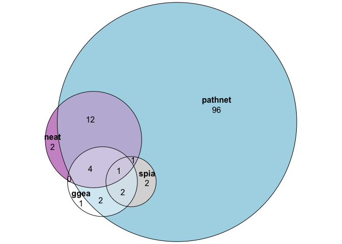

```r
library(eulerr)
plot(euler(sig_path_list), quantities = TRUE)
```

The results shows the results from different methods actually varies a lot.

If we also compare to GSEA method.

```r
res_gsea = sbea(method = "gsea", se = se, gs = hsa.gs)
res_gsea_tb = gsRanking(res_gsea, signif.only = FALSE)
res_gsea_tb$fdr = p.adjust(res_gsea_tb$PVAL, "BH")
sig_pathway_gsea = res_gsea_tb$GENE.SET[res_gsea_tb$fdr < 0.05]
length(sig_pathway_gsea)
```

```
## [1] 0
```

Unfortunately, there is no significant pathways.